# Milestone Report

Scott Brenstuhl

March 12, 2016

## Summary

Using the bodies of text samples provided by Coursera I am building an app to predict what the next word will be when the beginning of a phrase is entered. In this exploratory analysis I will share information about the data, my initial findings and my plans of how to move forward with the app.

## The Data

Coursera provides all of the data here:  
https://d396qusza40orc.cloudfront.net/dsscapstone/dataset/Coursera-SwiftKey.zip  
I am only taking the en_US sub-directory into consideration. If we look at all the data we see that it is massive:

```
## [1] "The Twitter data has 2360148 rows and 30093369 words."
```

```
## [1] "The blog data has 899288 rows and 37546246 words."
```

```
## [1] "The news data has 1010242 rows and 34762395 words."
```

Since these are so massive, I took a 1% sample of each for exploration. This brings the size of our data to a lot more manageable size:

```
## [1] "The Twitter sample has 23601 rows and 301414 words."
```

```
## [1] "The blog sample has 8993 rows and 370203 words."
```

```
## [1] "The news sample has 10102 rows and 340461 words."
```

## Data Prep

Since this app will be used to predict the next word, we aren’t going to want to suggest profanity (at least without the user opting into it). So for the analysis I removed everything from this fantastic list:  
https://github.com/shutterstock/List-of-Dirty-Naughty-Obscene-and-Otherwise-Bad-Words/blob/master/en

I also dropped all twitter handles, hastags, and “RT:”s since predicting them seems outside the scope of this project. I have also removed unicode characters and numbers to focus on text.

## Interesting Findings

### Unigrams

There are many, many, more words that are used rarely than those that are used extremely frequently. This pulls the histogram so far towards low numbers that the high frequency words aren’t even visible.

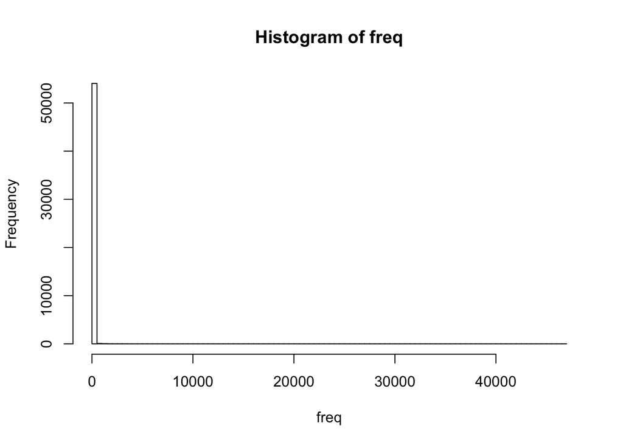

To highlight how many words are used only a handful of times and how frequently the most common words are used in a more visible way, I plotted the amount of times each frequency occurs.

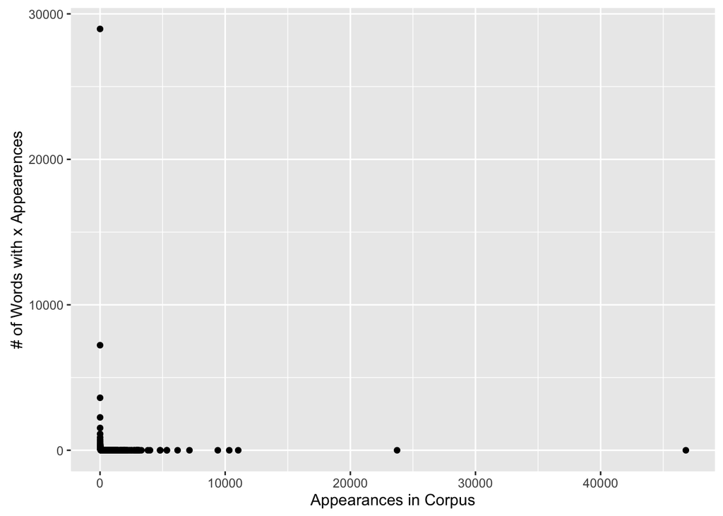

If we look at the top twenty most commonly used words and their occurrences, we can see just how dominate the most common stop words are. Even compared to the top 50 most used words, “the” and “and” tower over the rest of the words.

```
##      occurences
## the       46810
## and       23735
## for       11041
## that      10325
## you        9409
## with       7144
## was        6196
## this       5342
## have       5339
## are        4812
## but        4794
## not        3992
## from       3824
## all        3305
## they       3167
## will       3099
## your       3056
## its        3044
## just       3044
## said       2981
```

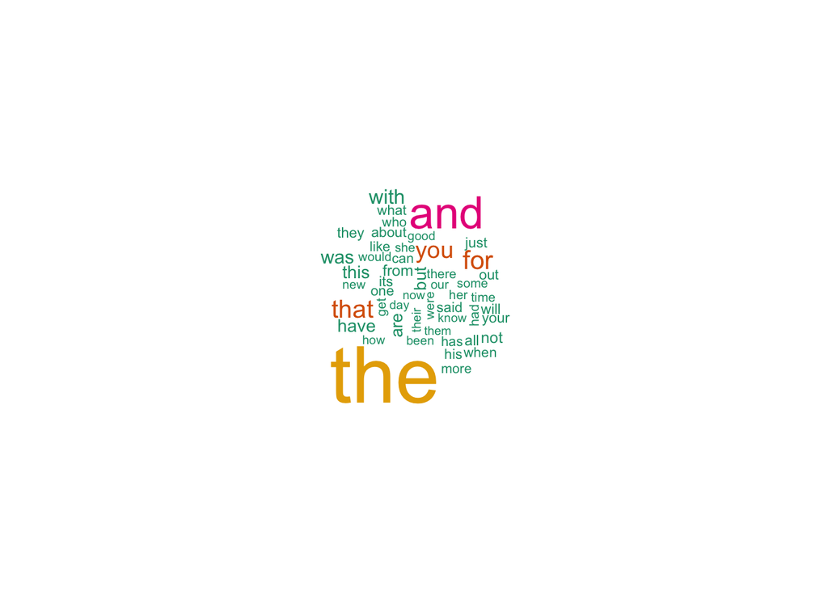

If we also look at these same breakdowns with stop-words removed, we don’t see anything too surprising, they are all words we are used to commonly seeing.

```
##        occurences
## will         3099
## just         3044
## said         2981
## one          2893
## like         2695
## can          2553
## get          2231
## time         2125
## new          1929
## good         1833
## now          1713
## day          1703
## know         1658
## love         1588
## people       1561
## dont         1420
## back         1399
## first        1350
## see          1344
## make         1279
```

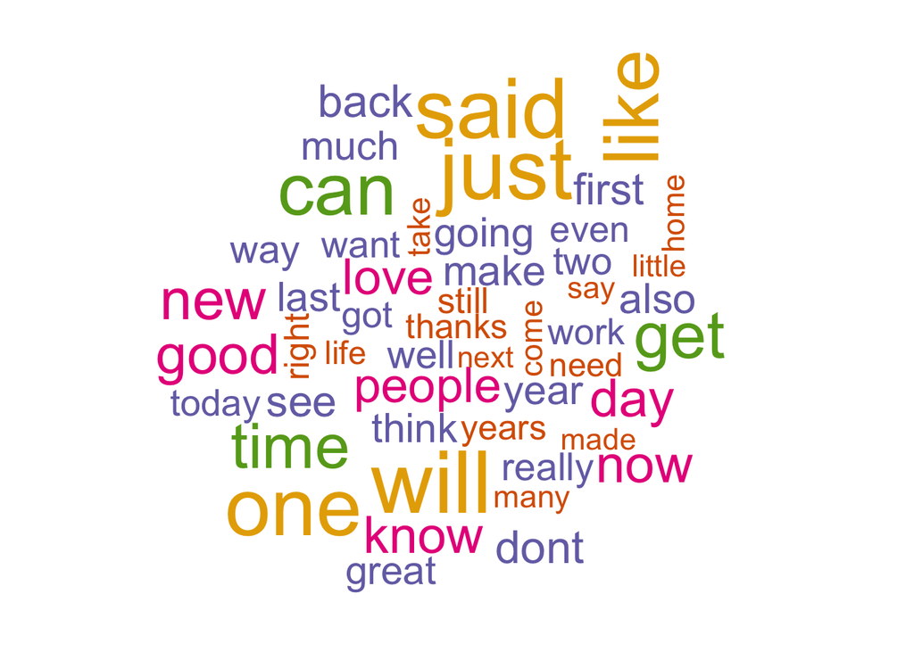

### N-grams

We can repeat basically the same exercise on n-grams two to four words in length. The histogram for this is so similarly skewed towards single digits that it isn’t worth showing. Plotting the frequency of occurrence counts is also rather similar:

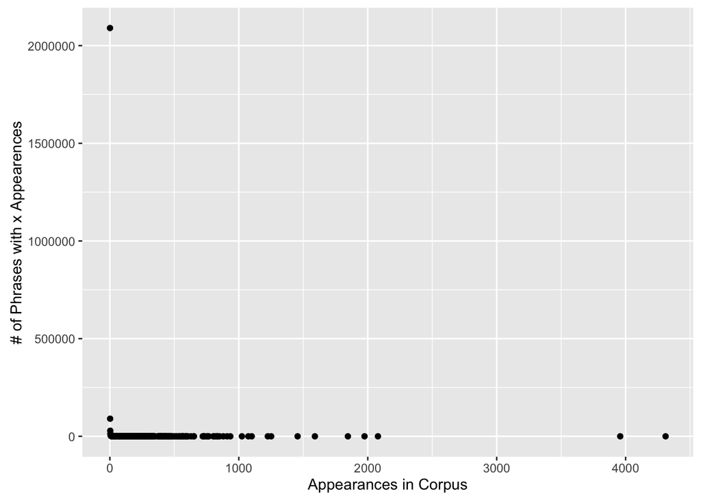

When we look at the most common n-grams, unsurprisingly it’s basically just combinations of common stop-words.

```
##          occurences
## of the         4310
## in the         3958
## to the         2079
## for the        1975
## on the         1846
## to be          1590
## at the         1456
## and the        1251
## in a           1225
## with the       1100
## is a           1074
## it was         1024
## for a           934
## i have          909
## from the        880
## and i           851
## with a          836
## i was           834
## will be         824
## it is           811
```

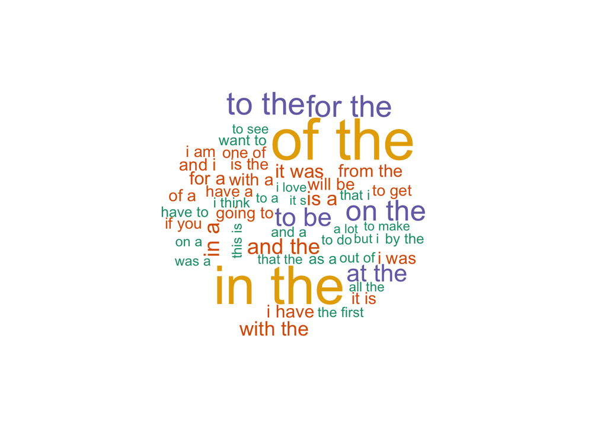

Then when we remove the common stop-words it gets a little more interesting, with phrases we are used to seeing: * When things happen: right now, last year, years ago, etc. * City names: New York, New Jersey, and St. Louis * Common statements: Good morning, happy birthday

```
##                 occurences
## right now              243
## last year              216
## new york               208
## cant wait              165
## im going               150
## high school            148
## feel like              147
## dont know              144
## last night             134
## first time             128
## years ago              125
## can get                123
## last week              114
## looking forward        114
## looks like             102
## make sure              100
## new jersey              95
## st louis                94
## good morning            93
## happy birthday          88
```

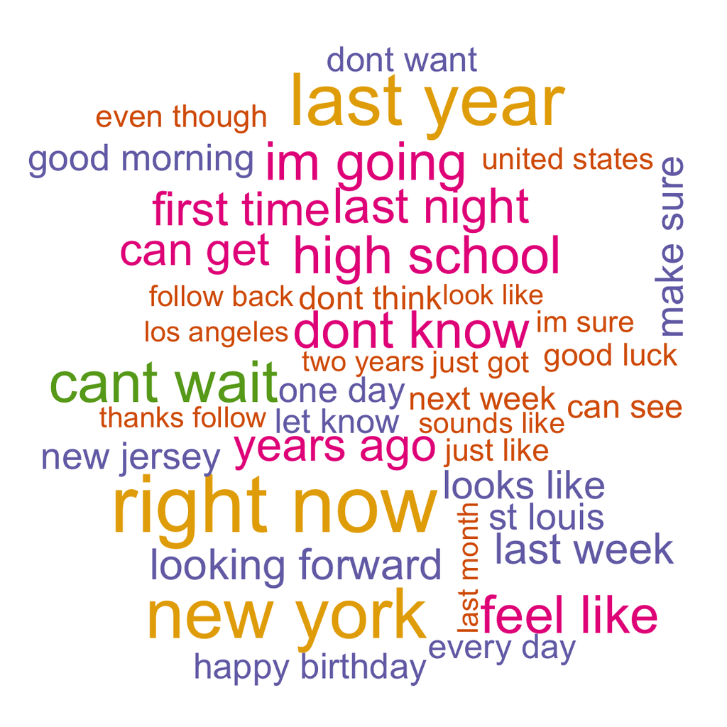

## Plans for prediction algorithm and app

A few things to improve data integrity:

- Check for repetitive long n-grams (are likely bad to keep if they are just boilerplate items in blogs or news).
- Consider remove duplicate tweets since if they are just copies their phrases aren’t actually more common.
- Once everything is working use a larger sample than 1% and see if it improves results.
- Potentially convert my tm functions to quanteda fuctions so that it runs faster.

For the algorithm:

- Figure out how to spit the last word off all the n-grams and find probability of what word will follow it.
- Turn that into a marcov chain to use when predicting the next word.
- Learn more about back off models and smoothing algorithms since they both sound like they will lead to better predictions.
- Possibly figure out how to include profanity in the marcov chains, so that we can predict more accurately, but not suggest it (without them opting in to such a thing.)

The app

- Hopefully this part will be pretty straightforward once everything else is done. I am planning to just return the most likely answer when text is entered by the user. If it’s possible to do so fast enough, I would love to return the top three most likely next words.
- It would also be cool to log the users entries above where they type, so that they can do multiple sentences/entries and see them all.
- If simple enough, it would be interesting to let user choose to have profanity predicted or not.